# 2022 RESIDENTIAL RENTAL MARKET DATASET: PROPERTY LISTINGS IN KOLKATA AND MUMBAI

## What is the premium (in percentage) for properties in "Carpet Area" versus "Super Area" listings for the same locality?

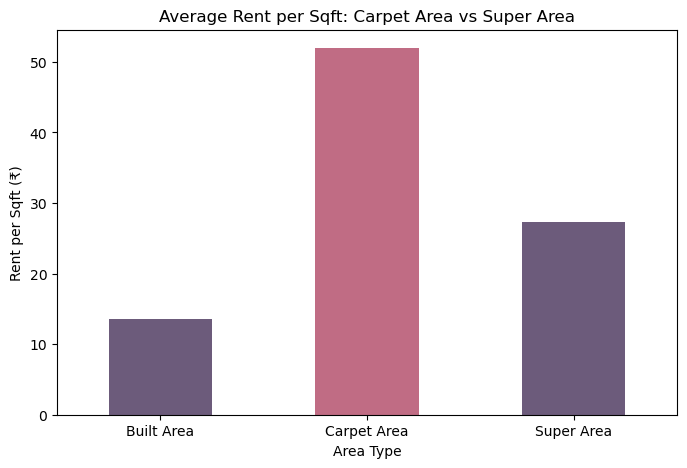

```python
# Calculate average rent per sqft by area type
area_premium = df.groupby('Area Type')['Rent_Per_Sqft'].mean()

# Plot bar chart
plt.figure(figsize=(8, 5))
area_premium.plot(kind='bar', color=['#6C5B7B', '#C06C84'])
plt.title('Average Rent per Sqft: Carpet Area vs Super Area')
plt.xlabel('Area Type')
plt.ylabel('Rent per Sqft (₹)')
plt.xticks(rotation=0)
plt.savefig("Carpet Area vs Super Area.png")
plt.show()
```

## Which neighborhoods offer the best rent-to-size ratio for tenants seeking budget accommodations?

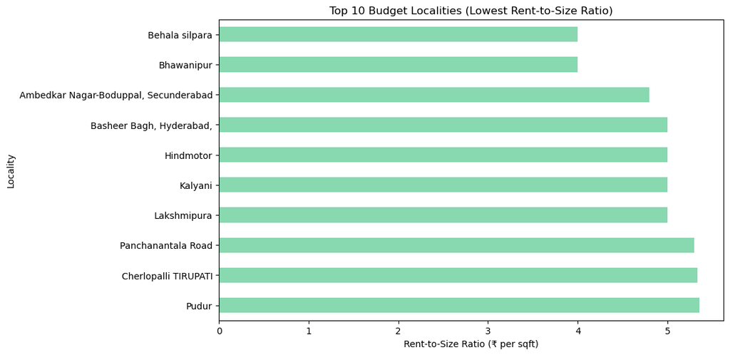

```python
# Calculate rent-to-size ratio and filter top 10 budget localities
df['Rent_to_Size'] = df['Rent'] / df['Size']
budget_localities = df.groupby('Area Locality')['Rent_to_Size'].mean().nsmallest(10)

# Plot horizontal bar chart
plt.figure(figsize=(10, 6))
budget_localities.plot(kind='barh', color='#88D8B0')
plt.title('Top 10 Budget Localities (Lowest Rent-to-Size Ratio)')
plt.xlabel('Rent-to-Size Ratio (₹ per sqft)')
plt.ylabel('Locality')
plt.gca().invert_yaxis()
plt.savefig("Lowest Rent-to-Size Ratio.png")
plt.show()
```

## Which localities in Kolkata/Mumbai have the highest concentration of unfurnished properties, and how does this affect tenant demand?

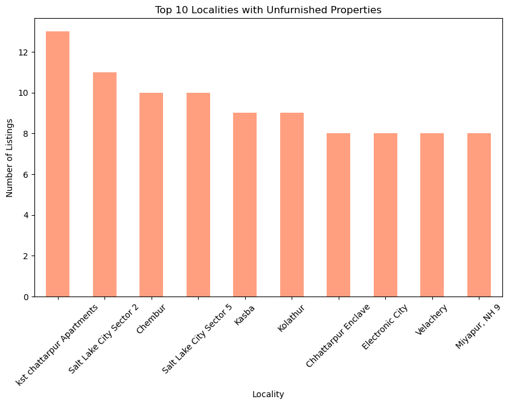

```python
# Filter unfurnished properties and count by locality
unfurnished = df[df['Furnishing Status'] == 'Unfurnished']
unfurnished_counts = unfurnished['Area Locality'].value_counts().head(10)

# Plot bar chart
plt.figure(figsize=(10, 6))
unfurnished_counts.plot(kind='bar', color='#FF9F80')
plt.title('Top 10 Localities with Unfurnished Properties')
plt.xlabel('Locality')
plt.ylabel('Number of Listings')
plt.xticks(rotation=45)
plt.savefig("Localities with Unfurnished Properties.png")
plt.show()
```

## Are there specific areas (e.g., Salt Lake City in Kolkata or Bandra West in Mumbai) where rental prices deviate significantly from city-wide averages?

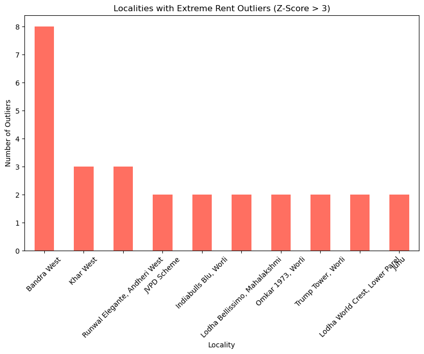

```python
# Calculate z-scores for rent and filter outliers
df['Rent_Z'] = (df['Rent'] - df['Rent'].mean()) / df['Rent'].std()
outliers = df[abs(df['Rent_Z']) > 3]

# Plot bar chart for outlier localities
plt.figure(figsize=(10, 6))
outliers['Area Locality'].value_counts().head(10).plot(kind='bar', color='#FF6F61')
plt.title('Localities with Extreme Rent Outliers (Z-Score > 3)')
plt.xlabel('Locality')
plt.ylabel('Number of Outliers')
plt.xticks(rotation=45)
plt.savefig("Localities with Extreme Rent Outliers.png")
plt.show()
```

## How did rental prices fluctuate month-over-month (Posted On) in 2022, and were there seasonal peaks in listings?

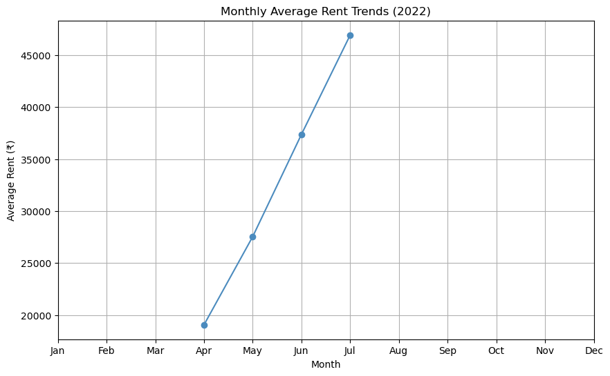

```python
# Extract month from Posted On and group
df['Posted_Month'] = pd.to_datetime(df['Posted On']).dt.month
monthly_rent = df.groupby('Posted_Month')['Rent'].mean()

# Plot line chart
plt.figure(figsize=(10, 6))
monthly_rent.plot(kind='line', marker='o', color='#4B8BBE')
plt.title('Monthly Average Rent Trends (2022)')
plt.xlabel('Month')
plt.ylabel('Average Rent (₹)')
plt.xticks(range(1, 13), ['Jan', 'Feb', 'Mar', 'Apr', 'May', 'Jun', 'Jul', 'Aug', 'Sep', 'Oct', 'Nov', 'Dec'])
plt.grid(True)
plt.savefig("Monthly Average Rent Trends (2022).png")
plt.show()
```

## Are newer listings (e.g., July 2022) priced higher than older ones (April 2022) for comparable properties?

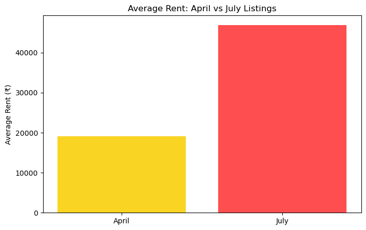

```python
# Compare April vs July average rents
apr_rent = df[df['Posted_Month'] == 4]['Rent'].mean()
jul_rent = df[df['Posted_Month'] == 7]['Rent'].mean()

# Plot bar chart
plt.figure(figsize=(8, 5))
plt.bar(['April', 'July'], [apr_rent, jul_rent], color=['#F9D423', '#FF4E50'])
plt.title('Average Rent: April vs July Listings')
plt.ylabel('Average Rent (₹)')
plt.savefig("April vs July Listings.png")
plt.show()
```

## Are there anomalies in the dataset, such as unusually high/low rent values for specific BHK sizes or localities?

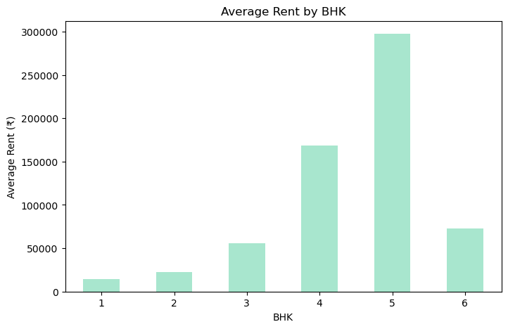

```python
# Box plot for BHK vs Rent (using bar chart alternative)
bhk_rent = df.groupby('BHK')['Rent'].mean()
plt.figure(figsize=(8, 5))
bhk_rent.plot(kind='bar', color='#A8E6CE')
plt.title('Average Rent by BHK')
plt.xlabel('BHK')
plt.ylabel('Average Rent (₹)')
plt.xticks(rotation=0)
plt.savefig("Average Rent by BHK.png")
plt.show()
```

## How consistent is the formatting of "Floor" data (e.g., "Ground out of 2" vs. "1 out of 3") across entries, and does this impact analysis?

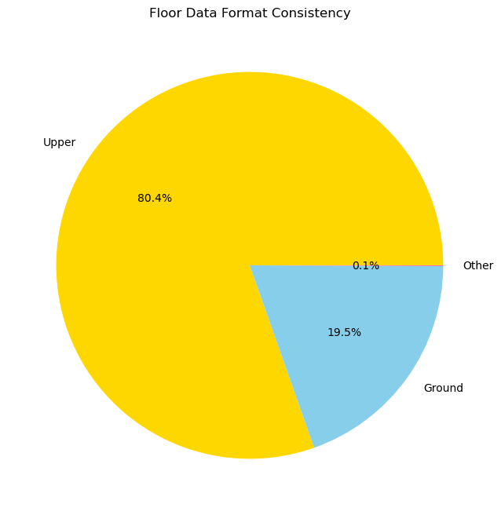

```python
# Analyze floor format consistency
floor_formats = df['Floor'].apply(lambda x: 'Ground' if 'Ground' in x else 'Upper' if 'out of' in x else 'Other')
floor_counts = floor_formats.value_counts()

# Plot pie chart
plt.figure(figsize=(8, 8))
floor_counts.plot(kind='pie', autopct='%1.1f%%', colors=['#FFD700', '#87CEEB', '#FF69B4'])
plt.title('Floor Data Format Consistency')
plt.ylabel('')
plt.savefig("Floor Data Format Consistency.png")
plt.show()
```

## Do duplicate entries (e.g., repeated listings for Jadavpur or Salt Lake City) suggest data collection errors or genuine reposts?

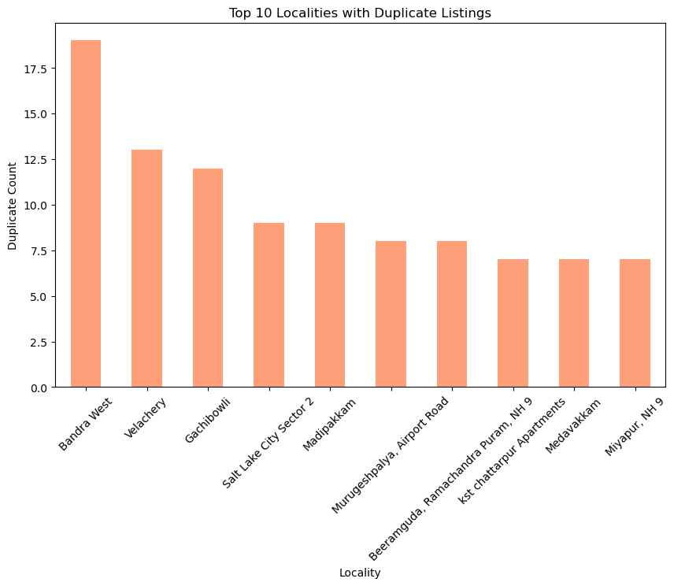

```python
# Identify duplicates based on BHK, Rent, and Locality
duplicates = df[df.duplicated(subset=['BHK', 'Rent', 'Area Locality'], keep=False)]
duplicate_counts = duplicates['Area Locality'].value_counts().head(10)

# Plot bar chart
plt.figure(figsize=(10, 6))
duplicate_counts.plot(kind='bar', color='#FFA07A')
plt.title('Top 10 Localities with Duplicate Listings')
plt.xlabel('Locality')
plt.ylabel('Duplicate Count')
plt.xticks(rotation=45)
plt.savefig("Localities with Duplicate Listings.png")
plt.show()
```